# Project_Red_Wines

## Get high alcohol level and high sulphates for better wines

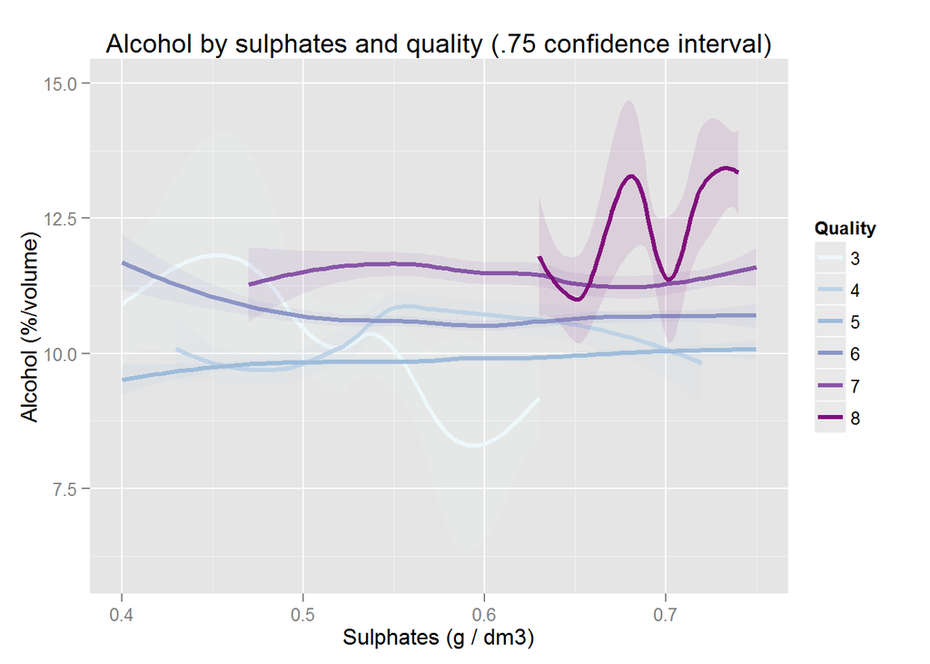

This graph shows smoothers of alcohol by sulphates for all quality. Quality and alcohol have a strong correlation at 0.476. The correlation between quality and sulphates is weaker at 0.251 but still present.  
The low quality (3) wines vary a lot but the overal trend is that they are high in alcohol with low sulphates and the alcohol level decreases as the sulphates level increases. Qualities 4 to 7 are flat overall and the only differences come from the alcohol level.  
Quality 8 wines are peculiar in that they are grouped in the top right corner. The relationship is not flat like the other quality (except 3) but those wines have more alcohol and more sulphates.

# Reflection

I started the analysis by looking at the data overal. Some data points seemed really far out and during the analysis, I removed some of them. But I decided to keep them in the end as wine tastes can vary greatly.  
Looking at the different variables, I decidied to investigate what made a wine good. I started by looking at the main things that could affect taste: alcohol, chlorides, residual.sugar and pH. My first finding was really about alcohol and quality.  
I then moved to multivariables analyses by combining alcohol with chlorides and residual.sugar. The overall trends by quality looked quite similar so I tried to plot chlorides with residual.sugar. But the results was not what I was expecting. Thinking that another factor might be related with those two, I went through the the acidity variables and the quality to select volatile.acidity and citric.acidity and plot them with chlorides and residual.sugar. The plots seemed to give something for citric.acid byt I was overreading it, the correlation is low. I did the same exercice for the rest of the variables.  
I get all in all several variables correlating with quality: * Alcohol * Volatile acidity (negative correlation) * Citric acid * Sulphates I was looking for some more adavanced relations between the variables but was not able to find them. I am especially surprised that residual.sugar and chlorides does not affect quality more.  
The limits of the dataset are really the lack of points on the lower and higher quality wines. Futhermore, the source of the quality is unknown, is it from a professionnal? A store? And we have to keep in mind that taste is a really cultural thing (see the [indian food analysis](http://www.washingtonpost.com/blogs/wonkblog/wp/2015/03/03/%20a-scientific-explanation-of-what-makes-indian-food-so-delicious/)) and a good wine for someone might not be for another. Last but not least, we do not have the age of the wine. In France, one of the first thing we check for a wine is its age because common knowledge dictates that an older wine is better than a younger one (for “normal” year). I would have love to validate or discard this coutume. Another thing that I would like is to get the name of the wines so that I can get their prices and see if how they relate to quality.